# Tugas5_MPDW

Raden Roro Jessica Faaris

2025-10-01

```r
library(ggplot2)
library(tsibble)
library(tseries)
library(MASS)
```

# Input Data

```r
data <- read.csv("https://raw.githubusercontent.com/bluejeasy/mpdw/refs/heads/main/ice_cream.csv")
data$DATE <- as.Date(data$DATE)
subset_data <- data[461:575, ]
head(subset_data)
```

```
##           DATE IPN31152N
## 461 2010-05-01  134.5576
## 462 2010-06-01  143.9519
## 463 2010-07-01  128.8566
## 464 2010-08-01  125.5563
## 465 2010-09-01  116.0686
## 466 2010-10-01   97.7520
```

# Stasioner dalam Rataan dan Ragam

## Plot Time Series

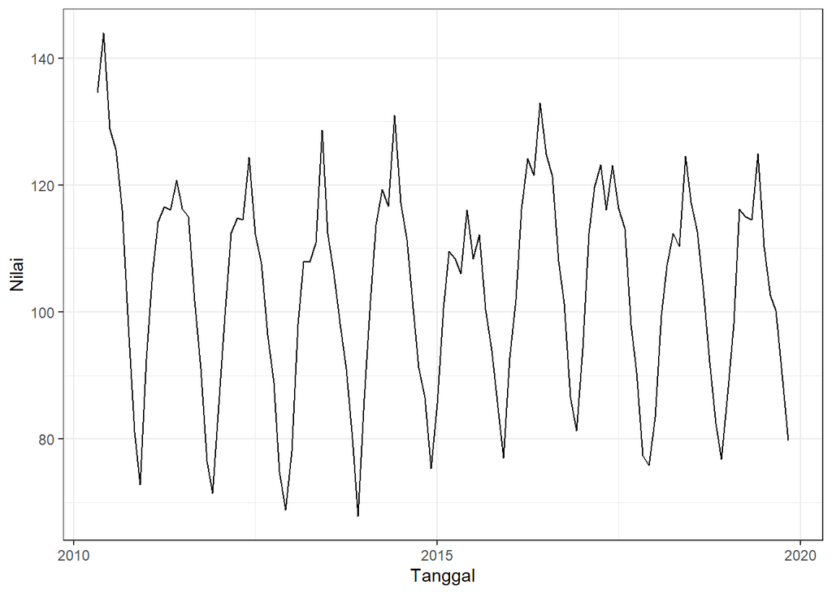

```r
plot_subset <- subset_data |>
  as_tsibble(index = DATE) |>
  ggplot(aes(x = DATE, y = IPN31152N)) +
  geom_line() +
  theme_bw() +
  xlab("Tanggal") +
  ylab("Nilai")

plot_subset
```

```r
mean(subset_data$IPN31152N)
```

```
## [1] 103.6137
```

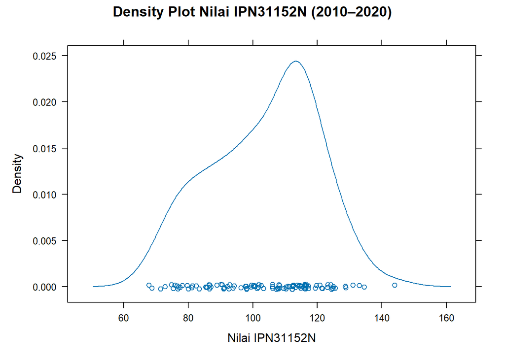

```r
library(lattice)

densityplot(as.vector(subset_data$IPN31152N),
            main = "Density Plot Nilai IPN31152N (2010–2020)",
            xlab = "Nilai IPN31152N")
```

Hasil visualisasi deret waktu menunjukkan bahwa data bersifat stasioner dalam rataan, ditunjukkan oleh fluktuasi yang konsisten di sekitar nilai tengahnya (±18). Selain itu, data juga stasioner dalam ragam karena variasi yang ditampilkan relatif konstan sepanjang periode pengamatan.

## Plot ACF

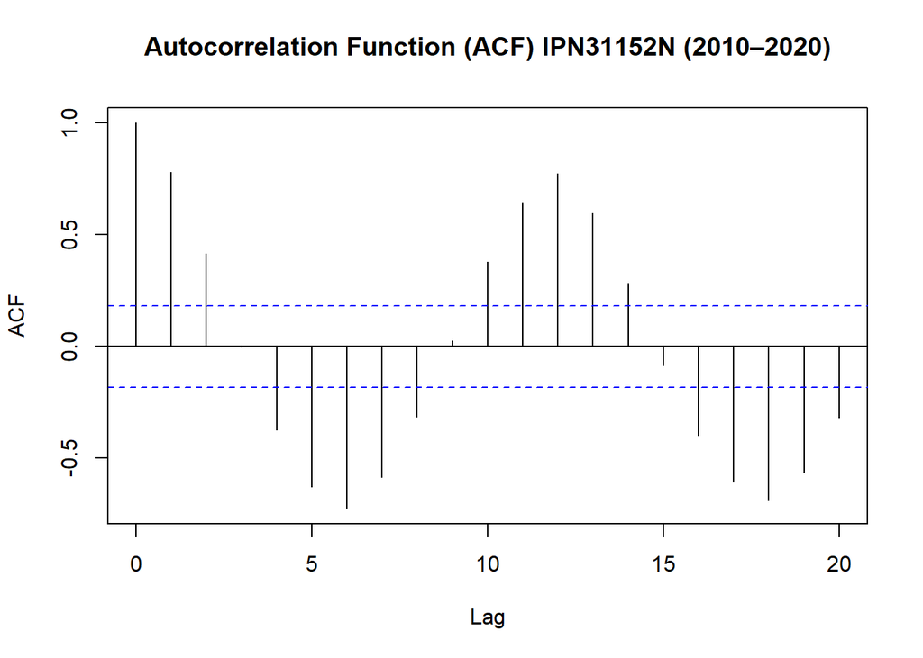

```r
# ACF untuk subset data
acf(subset_data$IPN31152N,
    main = "Autocorrelation Function (ACF) IPN31152N (2010–2020)")
```

Berdasarkan plot ACF, terlihat bahwa nilai autokorelasi menunjukkan pola yang cenderung tails off secara bertahap dan membentuk gelombang sinusoidal, yang mengindikasikan adanya komponen musiman dalam data deret waktu.

## Uji ADF

```r
library(tseries)

# ADF Test untuk subset data
adf.test(subset_data$IPN31152N)
```

```
##
##  Augmented Dickey-Fuller Test
##
## data:  subset_data$IPN31152N
## Dickey-Fuller = -8.3684, Lag order = 4, p-value = 0.01
## alternative hypothesis: stationary
```

$H_0$: Data tidak stasioner dalam rataan

$H_1$: Data stasioner dalam rataan

Berdasarkan uji ADF diperoleh statistik uji sebesar -8.3684 dengan p-value = 0.01 yang lebih kecil dari taraf nyata 5%. Dengan demikian, $H_0$ ditolak dan dapat disimpulkan bahwa data stasioner dalam rataan. Hasil ini konsisten dengan eksplorasi awal menggunakan plot deret waktu serta plot ACF yang menunjukkan kestasioneran data.

## Plot Box-Cox

```r
library(MASS)

# Index untuk subset data (115 data: 461–575)
index <- seq(1:nrow(subset_data))

# Buat model regresi sederhana (value ~ index)
model <- lm(subset_data$IPN31152N ~ index)

# Box-Cox dengan rentang lambda -1 sampai 4
bc <- boxcox(
  model,
  lambda = seq(-1, 4, by = 0.01),
  main = "Box-Cox Transformation untuk IPN31152N"
)
```

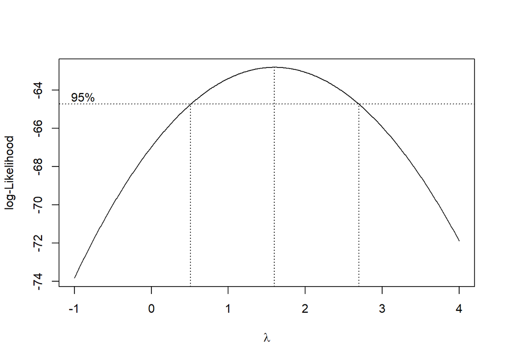

```r
# Nilai lambda optimum
lambda <- bc$x[which.max(bc$y)]
lambda
```

```
## [1] 1.6
```

```r
# Selang kepercayaan 95% untuk lambda
ci_lambda <- bc$x[bc$y > max(bc$y) - 0.5 * qchisq(0.95, 1)]

# Batas bawah dan batas atas
ci_lower <- min(ci_lambda)
ci_upper <- max(ci_lambda)

c(Batas_Bawah = ci_lower, Batas_Atas = ci_upper)
```

```
## Batas_Bawah  Batas_Atas
##        0.52        2.69
```

Gambar di atas menunjukkan nilai λ optimum sebesar 1,6 dengan selang kepercayaan 95% pada rentang (0,52 ; 2,69). Selang kepercayaan tersebut memuat nilai 1 sehingga dapat disimpulkan bahwa data stasioner dalam ragam.

## Partisi Data Deret Waktu

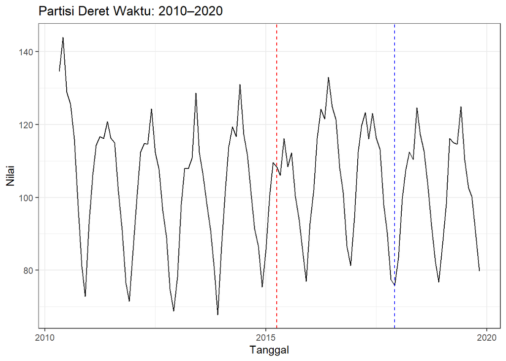

```r
library(ggplot2)
library(tsibble)

plot_subset <- subset_data |>
  as_tsibble(index = DATE) |>
  ggplot(aes(x = DATE, y = IPN31152N)) +
  geom_line() +
  theme_bw() +
  xlab("Tanggal") +
  ylab("Nilai") +

  # Tambahkan garis batas (contoh pakai tanggal)
  geom_vline(xintercept = as.Date("2015-04-01"),
             linetype = "dashed", color = "red") +
  geom_vline(xintercept = as.Date("2017-12-01"),
             linetype = "dashed", color = "blue") +
  ggtitle("Partisi Deret Waktu: 2010–2020")

plot_subset
```

# Bagian 1: Observasi 1-60

```r
# Bagian 1: observasi 1–60 dari subset_data
dt_stas1 <- ts(subset_data[1:60, "IPN31152N"])

# Rata-rata Bagian 1
mean(dt_stas1)
```

```
## [1] 103.0302
```

```r
# Varians Bagian 1
var(dt_stas1)
```

```
## [1] 320.0992
```

## Plot Time Series

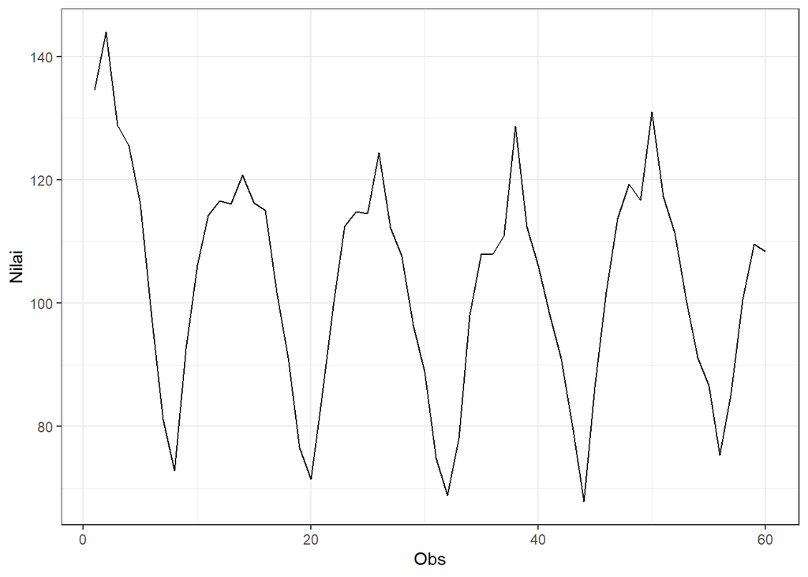

```r
# Bagian 1: observasi 1–60
dt_stas1 <- ts(subset_data[1:60, "IPN31152N"])

# Plot Bagian 1
dt_stas1 |>
  as_tsibble() |>
  ggplot(aes(x = index, y = value)) +
  geom_line() +
  theme_bw() +
  xlab("Obs") +
  ylab("Nilai")
```

## Plot ACF

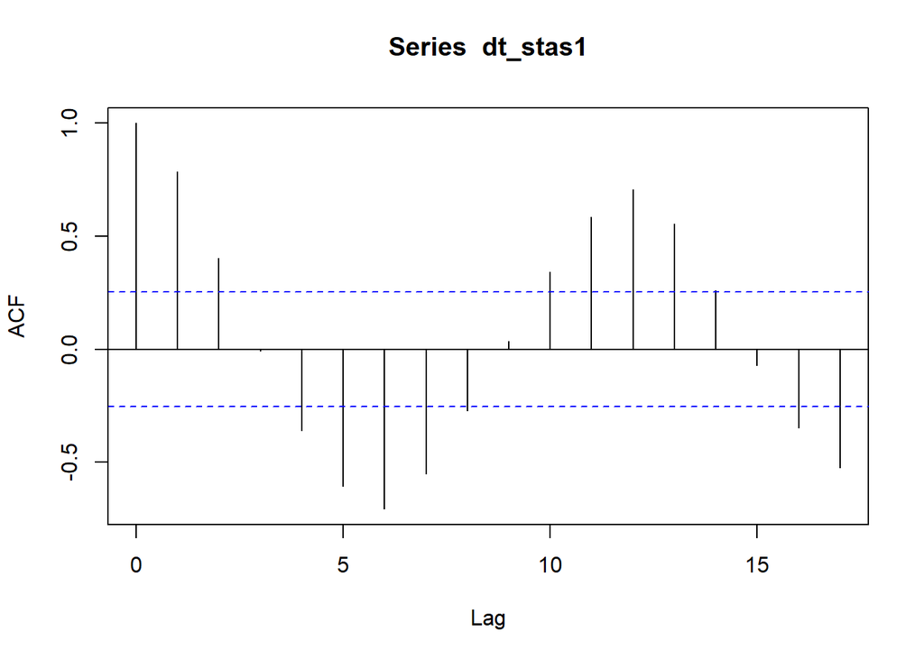

```r
acf(dt_stas1)
```

Pola penurunan tidak langsung cut off, melainkan tails off secara bertahap dan tampak membentuk gelombang yang menyerupai sinus.

## Uji ADF

```r
tseries::adf.test(dt_stas1)
```

```
##
##  Augmented Dickey-Fuller Test
##
## data:  dt_stas1
## Dickey-Fuller = -5.7113, Lag order = 3, p-value = 0.01
## alternative hypothesis: stationary
```

$H_0$: Data tidak stasioner dalam rataan

$H_1$: Data stasioner dalam rataan

Berdasarkan uji ADF tersebut, diperoleh p-value sebesar 0.01 yang lebih kecil dari taraf nyata 5%, sehingga tolak $H_0$ dan menandakan bahwa data stasioner dalam rataan. Hasil ini konsisten dengan eksplorasi awal melalui plot deret waktu maupun plot ACF.

## Plot Box-Cox

```r
# Membuat index untuk data
index <- seq(1, length(dt_stas1))

# Box-Cox Transformation
bc <- boxcox(
  dt_stas1 ~ index,
  lambda = seq(-2, 6, by = 0.01)
)
```

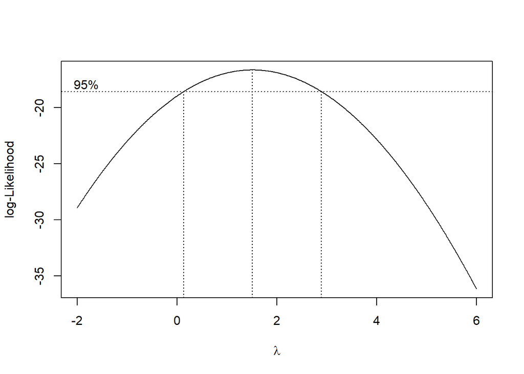

```r
# Nilai lambda optimum (dibulatkan)
lambda <- bc$x[which.max(bc$y)]
lambda
```

```
## [1] 1.51
```

```r
# Selang kepercayaan 95% untuk lambda
ci_lambda <- bc$x[bc$y > max(bc$y) - 0.5 * qchisq(0.95, 1)]

# Batas bawah dan batas atas
ci_lower <- min(ci_lambda)
ci_upper <- max(ci_lambda)

c(Batas_Bawah = ci_lower, Batas_Atas = ci_upper)
```

```
## Batas_Bawah  Batas_Atas
##        0.14        2.89
```

Gambar di atas menunjukkan nilai rounded value (λ) optimum sebesar 1,5 dan pada selang kepercayaan 95% nilai memiliki batas bawah 0,14 dan batas atas 2,89. Selang tersebut memuat nilai satu sehingga dapat dikatakan bahwa data dt_stas1 stasioner dalam ragam.

# Bagian 2: Observasi 1-100

## Plot Time Series

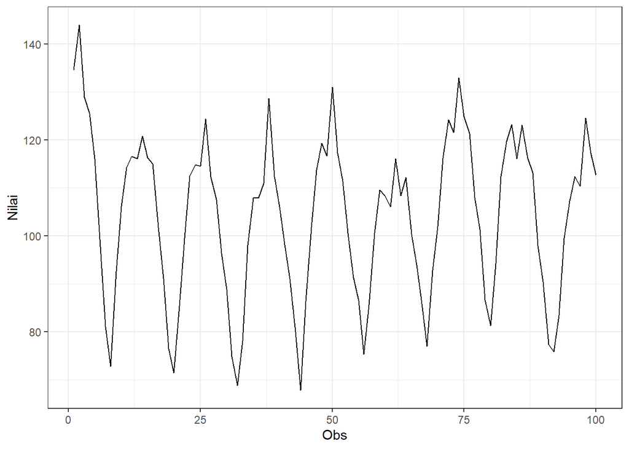

```r
# Bagian 2: observasi 1–100
dt_stas2 <- ts(subset_data[1:100, "IPN31152N"])

# Plot Bagian 2
dt_stas2 |>
  as_tsibble() |>
  ggplot(aes(x = index, y = value)) +
  geom_line() +
  theme_bw() +
  xlab("Obs") +
  ylab("Nilai")
```

## Plot ACF

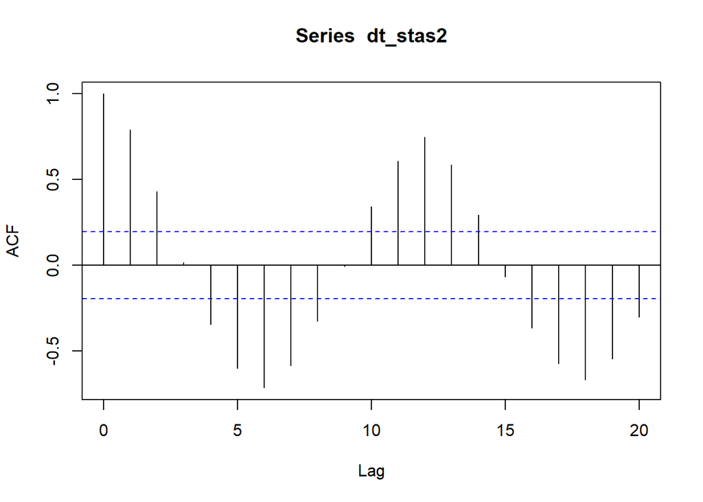

```r
acf(dt_stas2)
```

Pola autokorelasi tidak menunjukkan penurunan yang langsung cut off, melainkan tails off secara bertahap dan membentuk gelombang yang menyerupai sinus.

## Uji ADF

```r
tseries::adf.test(dt_stas2)
```

```
##
##  Augmented Dickey-Fuller Test
##
## data:  dt_stas2
## Dickey-Fuller = -7.7897, Lag order = 4, p-value = 0.01
## alternative hypothesis: stationary
```

$H_0$: Data tidak stasioner dalam rataan

$H_1$: Data stasioner dalam rataan

Berdasarkan uji ADF tersebut, diperoleh p-value sebesar 0.01 yang lebih kecil dari taraf nyata 5%, sehingga tolak $H_0$, menandakan bahwa data stasioner dalam rataan. Hasil ini konsisten dengan eksplorasi awal melalui plot deret waktu maupun plot ACF.

## Plot Box-Cox

```r
# Membuat index untuk data
index <- seq(1, length(dt_stas2))

# Box-Cox Transformation
bc <- boxcox(
  dt_stas2 ~ index,
  lambda = seq(-2, 6, by = 0.01)
)
```

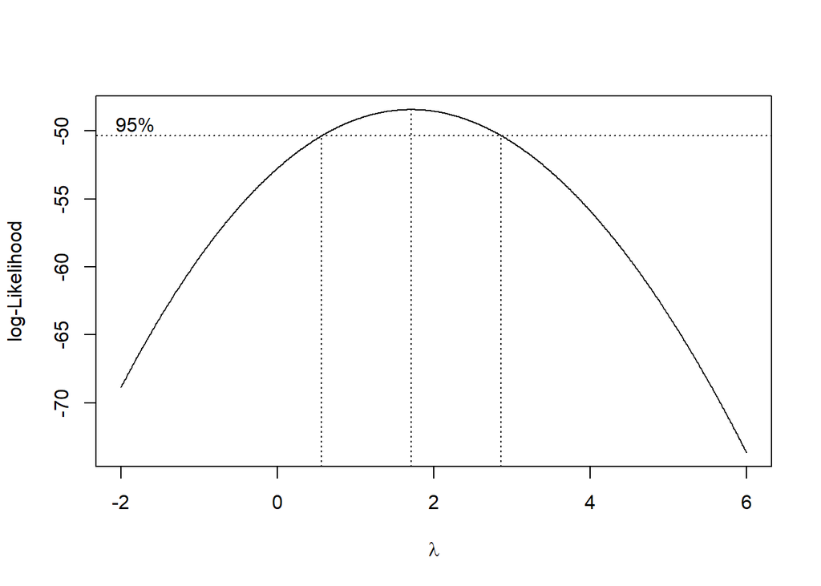

```r
# Nilai lambda optimum (dibulatkan)
lambda <- bc$x[which.max(bc$y)]
lambda
```

```
## [1] 1.71
```

```r
# Selang kepercayaan 95% untuk lambda
ci_lambda <- bc$x[bc$y > max(bc$y) - 0.5 * qchisq(0.95, 1)]

# Batas bawah dan batas atas
ci_lower <- min(ci_lambda)
ci_upper <- max(ci_lambda)

c(Batas_Bawah = ci_lower, Batas_Atas = ci_upper)
```

```
## Batas_Bawah  Batas_Atas
##        0.57        2.86
```

Gambar di atas menunjukkan nilai rounded value (λ) optimum sebesar 1,7 dan pada selang kepercayaan 95% nilai memiliki batas bawah 0,57 dan batas atas 2,86. Selang tersebut memuat nilai satu sehingga dapat dikatakan bahwa data dt_stas2 stasioner dalam ragam.